# 5f: Lake Huron Modeling

[Nao Mimoto](https://nmimoto.github.io/) - [Dept. of Statistics](http://www.uakron.edu/stat/) : [The University of Akron](http://www.uakron.edu)

[Class Web Page](https://nmimoto.github.io/477/)

## 0. Preliminary

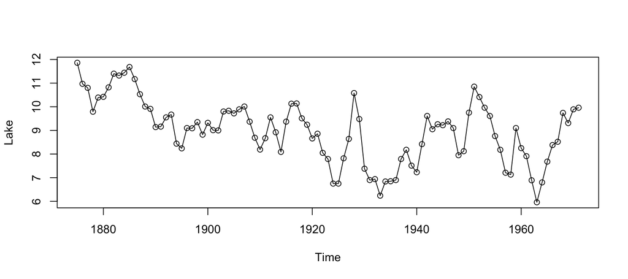

```r
  library(forecast)
  source('https://nmimoto.github.io/R/TS-00.txt')

  D = read.csv("https://nmimoto.github.io/datasets/lake.csv")
  Lake  = ts(D[,1], start=1875, freq=1)

  plot(Lake, type="o")
```

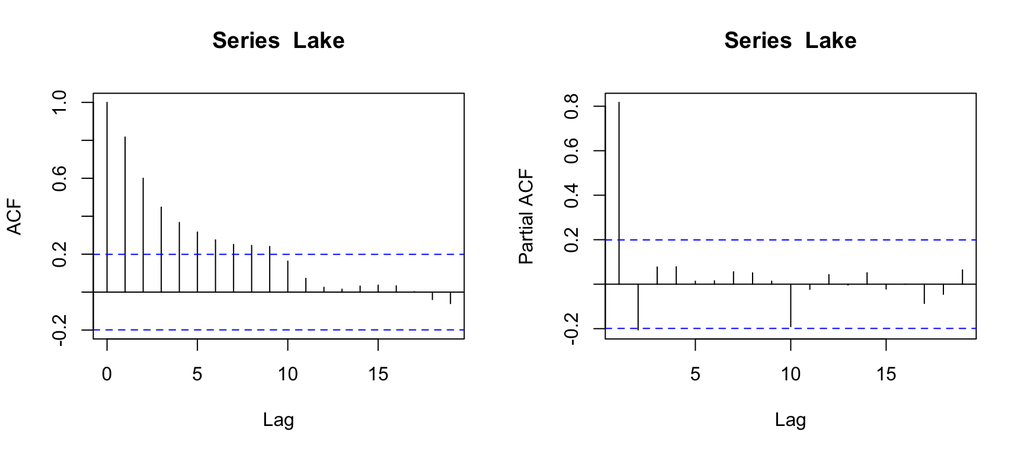

```r
  layout(matrix(c(1,2), 1, 2))
  acf(Lake)
  pacf(Lake)
```

```r
  layout(1)

  Stationarity.tests(Lake)
```

```
##        KPSS  ADF    PP
## p-val: 0.01 0.24 0.025
```

Stationarity tests results are mixed.

## 1. Direct ARMA fit

If we treat the series as “stationary”, we can try to fit ARMA(p,q) series. We’ve done this in earlier slides.

```r
  # find best ARMA(p,q) by AICc
  Fit1 = auto.arima(Lake, d=0, stepwise=FALSE, approximation=FALSE)
  Fit1
```

```
## Series: Lake
## ARIMA(1,0,1) with non-zero mean
##
## Coefficients:
##          ar1     ma1    mean
##       0.7665  0.3393  9.1290
## s.e.  0.0773  0.1123  0.3861
##
## sigma^2 = 0.4784:  log likelihood = -101.09
## AIC=210.18   AICc=210.62   BIC=220.48
```

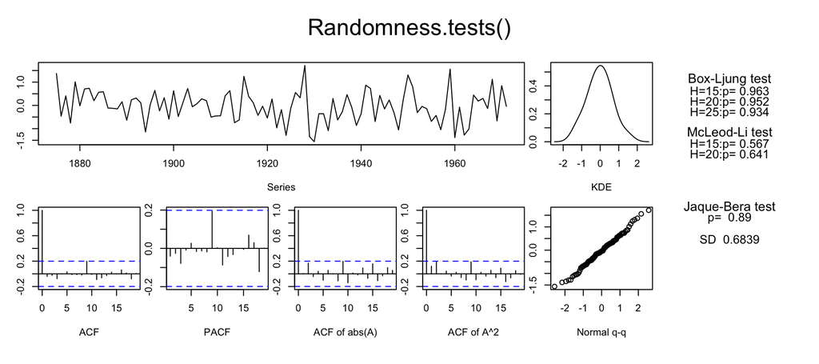

```
##   B-L test H0: the series is uncorrelated
##   M-L test H0: the square of the series is uncorrelated
##   J-B test H0: the series came from Normal distribution
##   SD         : Standard Deviation of the series
```

```
##       BL15  BL20  BL25  ML15  ML20   JB    SD
## [1,] 0.963 0.952 0.934 0.567 0.641 0.89 0.684
```

```r
  Randomness.tests(Fit1$residuals)
```

### Model 1 (ARIMA(1,0,1))

**auto.arima()** chooses ARMA(1,1) with mean via minimum AICc. With observation $Y_t$,
$$\begin{align*}
Y_t &= \mu + X_t \\
X_t &= \phi_1 X_{t-1} + \epsilon_t + \theta_1 \epsilon_{t-1} \\
\epsilon_t &\sim WN(0, \sigma^2) \\
\end{align*}$$

```r
  Fit1
```

```
## Series: Lake
## ARIMA(1,0,1) with non-zero mean
##
## Coefficients:
##          ar1     ma1    mean
##       0.7665  0.3393  9.1290
## s.e.  0.0773  0.1123  0.3861
##
## sigma^2 = 0.4784:  log likelihood = -101.09
## AIC=210.18   AICc=210.62   BIC=220.48
```

## 2. Linear Trend + ARMA

If we treat the series as “non-stationary”, we can try to fit a linear downward trend with ARMA errors.

Force linear regression by **xreg=time(Lake)**

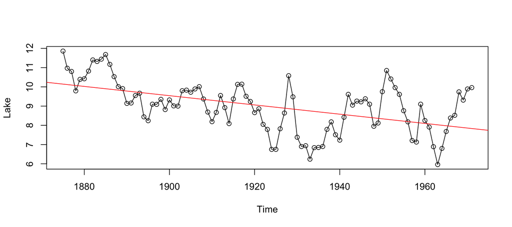

```r
  Reg2 = lm(Lake~time(Lake))

  plot(Lake, type="o")
  abline(Reg2, col="red")         # overlay regression line in red
```

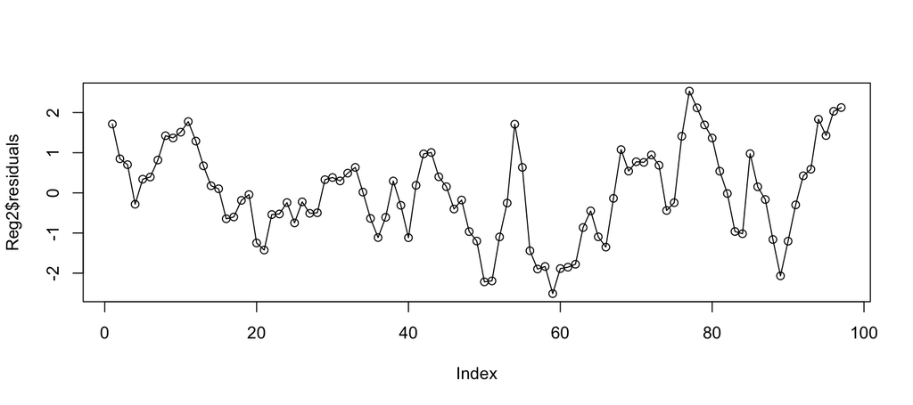

```r
  plot(Reg2$residuals, type="o")      # plot of the residuals from regression
```

```r
  Stationarity.tests(Reg2$residuals)
```

```
##        KPSS  ADF    PP
## p-val:  0.1 0.24 0.025
```

```r
  # fit the residuals with ARMA(p,q)
  Fit2 = auto.arima(Lake, d=0, xreg=time(Lake), stepwise=FALSE, approximation=FALSE)
  Fit2
```

```
## Series: Lake
## Regression with ARIMA(1,0,1) errors
##
## Coefficients:
##          ar1     ma1  intercept     xreg
##       0.6682  0.3817    55.5443  -0.0242
## s.e.  0.0936  0.1136    18.0324   0.0094
##
## sigma^2 = 0.4612:  log likelihood = -98.66
## AIC=207.33   AICc=207.98   BIC=220.2
```

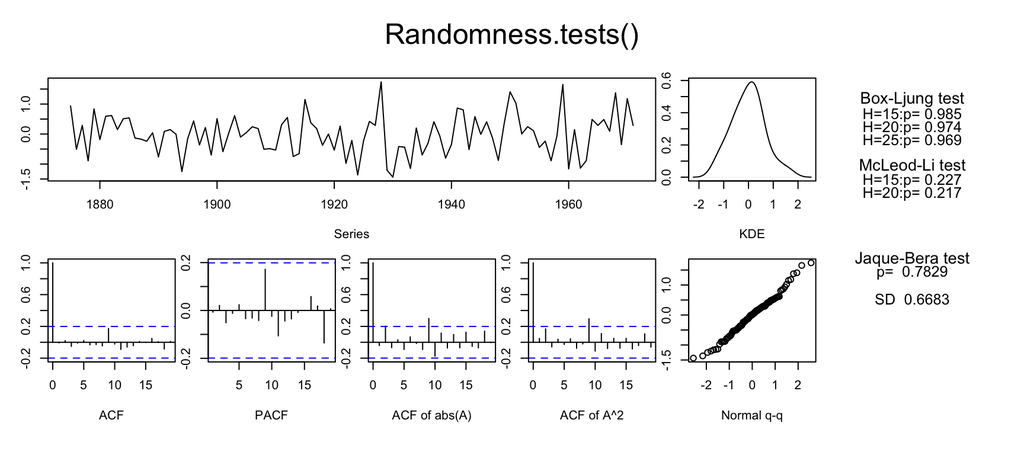

```
##   B-L test H0: the series is uncorrelated
##   M-L test H0: the square of the series is uncorrelated
##   J-B test H0: the series came from Normal distribution
##   SD         : Standard Deviation of the series
```

```
##       BL15  BL20  BL25  ML15  ML20    JB    SD
## [1,] 0.985 0.974 0.969 0.227 0.217 0.783 0.668
```

```r
  Randomness.tests(Fit2$resid)
```

```r
  Fit2
```

```
## Series: Lake
## Regression with ARIMA(1,0,1) errors
##
## Coefficients:
##          ar1     ma1  intercept     xreg
##       0.6682  0.3817    55.5443  -0.0242
## s.e.  0.0936  0.1136    18.0324   0.0094
##
## sigma^2 = 0.4612:  log likelihood = -98.66
## AIC=207.33   AICc=207.98   BIC=220.2
```

### Model 2 (linear trend + ARMA)

With observations $Y_t$, a linear trend was fit first, then the residuals were fitted with ARMA(1,1).

$$\begin{align*}
Y_t &= a + bt + X_t \\
X_t &= \phi_1 X_{t-1} + \epsilon_t + \theta_1 \epsilon_{t-1} \\
\epsilon_t &\sim WN(0, \sigma^2)
\end{align*}$$

```r
  Fit2
```

```
## Series: Lake
## Regression with ARIMA(1,0,1) errors
##
## Coefficients:
##          ar1     ma1  intercept     xreg
##       0.6682  0.3817    55.5443  -0.0242
## s.e.  0.0936  0.1136    18.0324   0.0094
##
## sigma^2 = 0.4612:  log likelihood = -98.66
## AIC=207.33   AICc=207.98   BIC=220.2
```

## 3. ARIMA modeling

We treat the series as “non-stationary”, but this time we use Box-Jenkins differencing to stationarize the data.

Note that **auto.arima()** INCLUDES drift term by default.

**Arima()** DOES NOT include drift term by default when d=1.

To force drift term in Arima(), use **include.drift=TRUE**

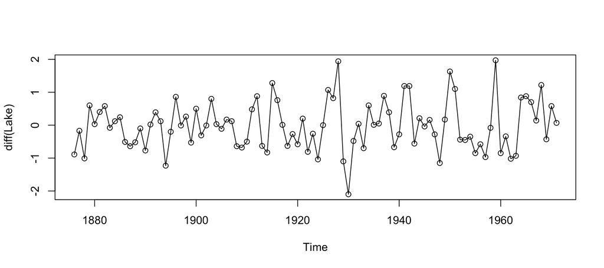

```r
  plot(diff(Lake), type='o')
```

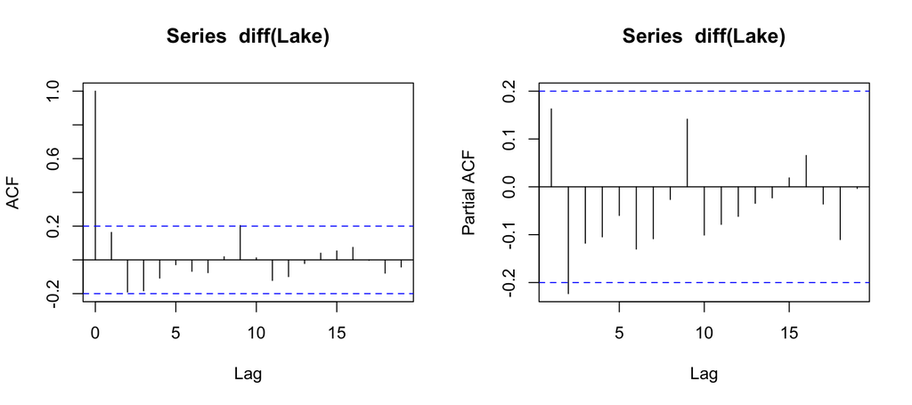

```r
  layout(matrix(1:2, 1, 2))
  acf(diff(Lake))
  pacf(diff(Lake))
```

```r
  layout(1)

  Stationarity.tests(diff(Lake))       # See if diff(Lake) is stationary
```

```
##        KPSS  ADF   PP
## p-val:  0.1 0.01 0.01
```

```r
  # Fit the difference of Lake with ARMA
  Fit3 = auto.arima(Lake, d=1, stepwise=FALSE, approximation=FALSE)
  Fit3
```

```
## Series: Lake
## ARIMA(1,1,2)
##
## Coefficients:
##          ar1      ma1      ma2
##       0.6385  -0.5349  -0.3514
## s.e.  0.1345   0.1445   0.1055
##
## sigma^2 = 0.4812:  log likelihood = -99.88
## AIC=207.76   AICc=208.2   BIC=218.02
```

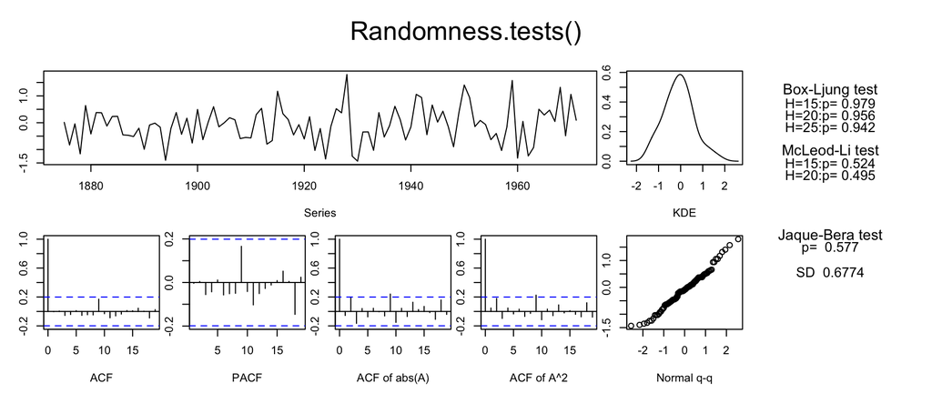

```
##   B-L test H0: the series is uncorrelated
##   M-L test H0: the square of the series is uncorrelated
##   J-B test H0: the series came from Normal distribution
##   SD         : Standard Deviation of the series
```

```
##       BL15  BL20  BL25  ML15  ML20    JB    SD
## [1,] 0.979 0.956 0.942 0.524 0.495 0.577 0.677
```

```r
  Randomness.tests(Fit3$residuals)
```

```r
  #-- Exactly same as above
  Fit3b = Arima(Lake, order=c(1,1,2))
  Fit3b
```

```
## Series: Lake
## ARIMA(1,1,2)
##
## Coefficients:
##          ar1      ma1      ma2
##       0.6385  -0.5349  -0.3514
## s.e.  0.1345   0.1445   0.1055
##
## sigma^2 = 0.4812:  log likelihood = -99.88
## AIC=207.76   AICc=208.2   BIC=218.02
```

```r
  #-- force drift term in the model
  Fit3c = Arima(Lake, order=c(1,1,2), include.drift=TRUE)
  Fit3c
```

```
## Series: Lake
## ARIMA(1,1,2) with drift
##
## Coefficients:
##          ar1      ma1      ma2    drift
##       0.6911  -0.6271  -0.3729  -0.0241
## s.e.  0.0956   0.1251   0.1157   0.0100
##
## sigma^2 = 0.4663:  log likelihood = -99
## AIC=208.01   AICc=208.67   BIC=220.83
```

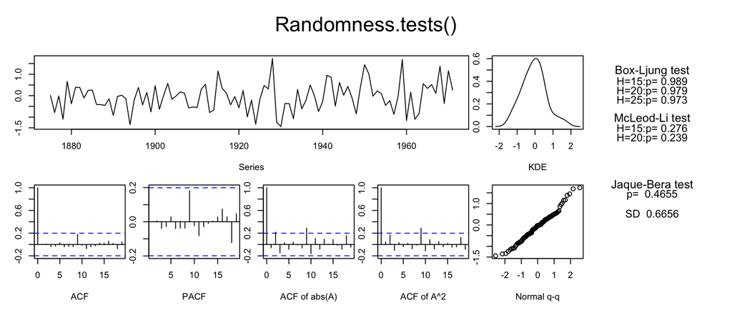

```
##   B-L test H0: the series is uncorrelated
##   M-L test H0: the square of the series is uncorrelated
##   J-B test H0: the series came from Normal distribution
##   SD         : Standard Deviation of the series
```

```
##       BL15  BL20  BL25  ML15  ML20    JB    SD
## [1,] 0.989 0.979 0.973 0.276 0.239 0.465 0.666
```

```r
  Randomness.tests(Fit3c$residuals)
```

### Model 3 (ARIMA(1,1,2))

With observations $Y_t$, a difference was taken. The difference seems to be ARMA(1,2).

In other words, $Y_t$ is ARIMA(1,1,2), meaning
$$\begin{align*}
Y_t &= M_t + Z_t \hspace{5mm} \mbox{ where } M_t \mbox{is RW w drift, } Z_t \mbox{ is stationary series.}\\
\bigtriangledown Y_t &= Y_t - Y_{t-1} = e_t + (Z_t-Z_{t-1}) = \delta + X_t \\
X_t &= \phi_1 X_{t-1} + \epsilon_t + \theta_1 \epsilon_{t-1} + \theta_2 \epsilon_{t-2} \\
\epsilon_t &\sim WN(0,\sigma^2)
\end{align*}$$

```r
  Fit3c
```

```
## Series: Lake
## ARIMA(1,1,2) with drift
##
## Coefficients:
##          ar1      ma1      ma2    drift
##       0.6911  -0.6271  -0.3729  -0.0241
## s.e.  0.0956   0.1251   0.1157   0.0100
##
## sigma^2 = 0.4663:  log likelihood = -99
## AIC=208.01   AICc=208.67   BIC=220.83
```

## 4. Another ARIMA model

Let’s look at the difference between the observations:

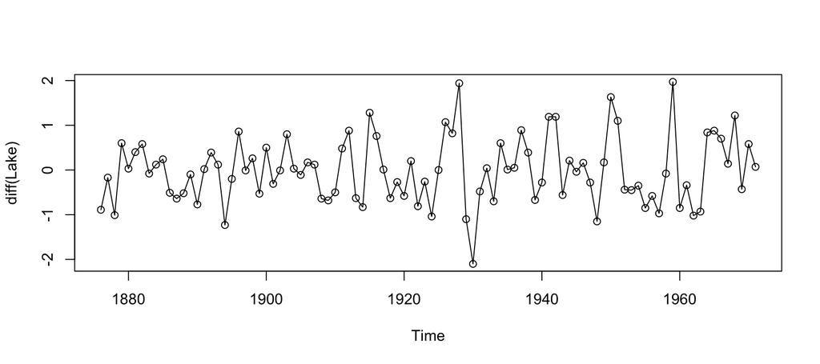

```r
  plot(diff(Lake), type='o')
```

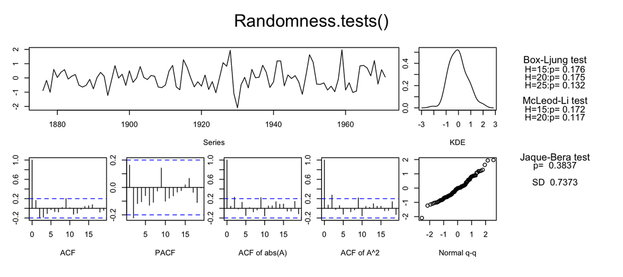

```
##   B-L test H0: the series is uncorrelated
##   M-L test H0: the square of the series is uncorrelated
##   J-B test H0: the series came from Normal distribution
##   SD         : Standard Deviation of the series
```

```
##       BL15  BL20  BL25  ML15  ML20    JB    SD
## [1,] 0.176 0.175 0.132 0.172 0.117 0.384 0.737
```

```r
  Randomness.tests(diff(Lake))
```

```r
  Fit4 = Arima(Lake, order=c(0,1,0))
  Fit4
```

```
## Series: Lake
## ARIMA(0,1,0)
##
## sigma^2 = 0.5383:  log likelihood = -106.49
## AIC=214.98   AICc=215.02   BIC=217.54
```

```r
  Fit4b = Arima(Lake, order=c(0,1,0), include.drift=TRUE)
  Fit4b
```

```
## Series: Lake
## ARIMA(0,1,0) with drift
##
## Coefficients:
##         drift
##       -0.0198
## s.e.   0.0749
##
## sigma^2 = 0.5435:  log likelihood = -106.45
## AIC=216.91   AICc=217.03   BIC=222.03
```

### Model 4 (ARIMA(0,1,0))

Difference of $Y_t$ seems to be Normal noise. That means $Y_t$ is RW without drift.

In other words, $Y_t$ is ARIMA(0,1,0), meaning
$$\begin{align*}
\bigtriangledown Y_t &= Y_t - Y_{t-1} = X_t \\
X_t &= \epsilon_t \\
\epsilon_t &\sim WN(0,\sigma^2)
\end{align*}$$

```r
    Fit4
```

```
## Series: Lake
## ARIMA(0,1,0)
##
## sigma^2 = 0.5383:  log likelihood = -106.49
## AIC=214.98   AICc=215.02   BIC=217.54
```

## 5. Model Summary

```r
  Fit1
```

```
## Series: Lake
## ARIMA(1,0,1) with non-zero mean
##
## Coefficients:
##          ar1     ma1    mean
##       0.7665  0.3393  9.1290
## s.e.  0.0773  0.1123  0.3861
##
## sigma^2 = 0.4784:  log likelihood = -101.09
## AIC=210.18   AICc=210.62   BIC=220.48
```

```r
  Fit2
```

```
## Series: Lake
## Regression with ARIMA(1,0,1) errors
##
## Coefficients:
##          ar1     ma1  intercept     xreg
##       0.6682  0.3817    55.5443  -0.0242
## s.e.  0.0936  0.1136    18.0324   0.0094
##
## sigma^2 = 0.4612:  log likelihood = -98.66
## AIC=207.33   AICc=207.98   BIC=220.2
```

```r
  Fit3c
```

```
## Series: Lake
## ARIMA(1,1,2) with drift
##
## Coefficients:
##          ar1      ma1      ma2    drift
##       0.6911  -0.6271  -0.3729  -0.0241
## s.e.  0.0956   0.1251   0.1157   0.0100
##
## sigma^2 = 0.4663:  log likelihood = -99
## AIC=208.01   AICc=208.67   BIC=220.83
```

```r
  Fit4
```

```
## Series: Lake
## ARIMA(0,1,0)
##
## sigma^2 = 0.5383:  log likelihood = -106.49
## AIC=214.98   AICc=215.02   BIC=217.54
```

## 6. Conclusion

- Model (1): ARIMA(1,0,1) with mean is fitting adequately. This suggests that Lake is stationary (at constant mean) without any transformation.

  $${\large Y_t \hspace{3mm} = \hspace{3mm} \mu + X_t, \hspace{10mm} X_t \mbox{ is ARMA(1,1)} }$$
- Model (2): ARIMA(1,0,1) with linear trend is fitting adequately. Intercept and slope are significant. However, the regression residuals are deemed non-stationary by ADF test.

  $${\large Y_t \hspace{3mm} = \hspace{3mm} a + bt + X_t, \hspace{10mm} X_t \mbox{ is ARMA(1,1)} }$$
- Model (3): ARIMA(1,1,2) with drift is fitting adequately. Drift is significant, and same as the slope in (b).

  $${\large \bigtriangledown Y_t = Y_t - Y_{t-1} = \delta + X_t, \hspace{10mm} X_t \mbox{ is ARMA(1,2)} }$$
- Model (4): ARIMA(0,1,0) is fitting adequately. This suggests that Lake is RW w/o drift. AICc was higher than that of Model 3.

  $${\large \bigtriangledown Y_t = Y_t - Y_{t-1} = X_t = \epsilon_t \hspace{10mm} \epsilon_t \mbox{ is ARMA(0,0) = WN} }$$
- Model (3) is the best candidate.